# Panel

Sergio Nava

2023-04-17

## Variables Dummy

Usaremos el conjunto de datos de *Salaries* [*car*], que contiene el salario académico de nueve meses de 2008-09 para profesores asistentes, profesores asociados y profesores en una universidad en los EE. UU. Los datos se recopilaron como parte del esfuerzo continuo de la administración de la universidad para monitorear las diferencias salariales entre los profesores masculinos y femeninos.

```r
# Load the data
data("Salaries", package = "carData")
# Inspect the data
str(Salaries)
```

```
## 'data.frame':    397 obs. of  6 variables:
##  $ rank         : Factor w/ 3 levels "AsstProf","AssocProf",..: 3 3 1 3 3 2 3 3 3 3 ...
##  $ discipline   : Factor w/ 2 levels "A","B": 2 2 2 2 2 2 2 2 2 2 ...
##  $ yrs.since.phd: int  19 20 4 45 40 6 30 45 21 18 ...
##  $ yrs.service  : int  18 16 3 39 41 6 23 45 20 18 ...
##  $ sex          : Factor w/ 2 levels "Female","Male": 2 2 2 2 2 2 2 2 2 1 ...
##  $ salary       : int  139750 173200 79750 115000 141500 97000 175000 147765 119250 129000 ...
```

```r
summary(Salaries)
```

```
##         rank     discipline yrs.since.phd    yrs.service        sex
##  AsstProf : 67   A:181      Min.   : 1.00   Min.   : 0.00   Female: 39
##  AssocProf: 64   B:216      1st Qu.:12.00   1st Qu.: 7.00   Male  :358
##  Prof     :266              Median :21.00   Median :16.00
##                             Mean   :22.31   Mean   :17.61
##                             3rd Qu.:32.00   3rd Qu.:27.00
##                             Max.   :56.00   Max.   :60.00
##      salary
##  Min.   : 57800
##  1st Qu.: 91000
##  Median :107300
##  Mean   :113706
##  3rd Qu.:134185
##  Max.   :231545
```

Una **variable indicadora**, o **variable ficticia**, es una variable de entrada que representa datos cualitativos, como género, raza, etc. Por lo general, las variables ficticias a veces se denominan variables binarias porque generalmente toman solo dos valores, 1 o 0, con 1 generalmente representando la presencia de una característica y 0 representando la ausencia. Por ejemplo, si tuviéramos una variable ficticia llamada *hombre*, 1 indicaría que el individuo es *hombre* y 0 indicaría que el individuo es *mujer* (o *no hombre* para ser más precisos). Usar un 1 y un 0 para representar la presencia o ausencia de una característica particular es arbitrario, pero como veremos, es muy conveniente. En general, podemos definir una variable ficticia D como

$$\begin{equation}
D =
\begin{cases}
1 & \text{si está presente la carcaterística}\\
0 & \text{si no está presente la característica}
\end{cases}
\end{equation}$$

Las variables ficticias se pueden utilizar para capturar cambios en la intersección, la pendiente o ambas del modelo, como veremos más adelante.

## Variables Dummy para intercepto

Quizás el uso más común de las variables ficticias es modificar el parámetro de intercepción del modelo de regresión. Agregar una variable indicadora D al modelo, junto con un $\beta_1$ nos da

$$\begin{equation}
y = \beta_0 + \beta_1 D + \beta_2 x +\epsilon
\end{equation}$$

Suponga que se tiene un modelo de regrsión donde *sex* representa *Male*(1) o *Female*(0). En nuestro modelo la variable independiente es *salary*, con otra variable independiente *yrs.service*, que indica la cantidad de años de servicio que tiene un profesor. El modelo se representa de la siguiente forma

$$\begin{equation}
E(salary) =
\begin{cases}
(\beta_0 + \beta_1)+\beta_2 yrs.service & sex=Male=1\\
\beta_0+\beta_2 yrs.service & sex=Female=0
\end{cases}
\end{equation}$$

```r
modelo1 <- lm(salary ~ sex + yrs.service , data = Salaries )
summary(modelo1)
```

```
##
## Call:
## lm(formula = salary ~ sex + yrs.service, data = Salaries)
##
## Residuals:
##    Min     1Q Median     3Q    Max
## -81757 -20614  -3376  16779 101707
##
## Coefficients:
##             Estimate Std. Error t value Pr(>|t|)
## (Intercept)  92356.9     4740.2  19.484  < 2e-16 ***
## sexMale       9071.8     4861.6   1.866   0.0628 .
## yrs.service    747.6      111.4   6.711 6.74e-11 ***
## ---
## Signif. codes:  0 '***' 0.001 '**' 0.01 '*' 0.05 '.' 0.1 ' ' 1
##
## Residual standard error: 28490 on 394 degrees of freedom
## Multiple R-squared:  0.1198, Adjusted R-squared:  0.1154
## F-statistic: 26.82 on 2 and 394 DF,  p-value: 1.201e-11
```

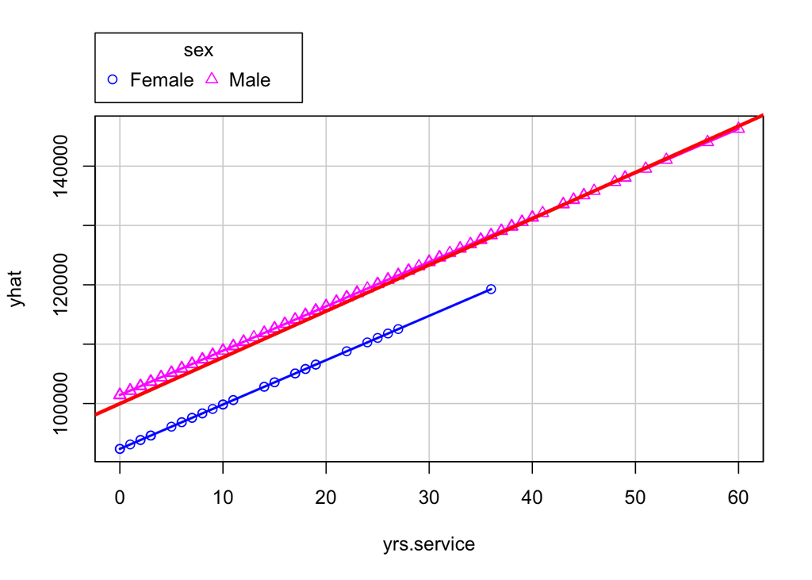

```r
yhat <- modelo1$fitted
scatterplot(yhat~yrs.service|sex, boxplots=FALSE, xlab="yrs.service", ylab="yhat",smooth=FALSE, data = Salaries)
abline(lm(salary ~ yrs.service, data=Salaries),lwd=3, col="red")
```

Para los hombres, el intercepto en el modelo es $(\beta_0 + \beta_1)=$ 92,356.95+9,071.8=101,428.7 y para las mujeres es $\beta_0=$ 92,356.95

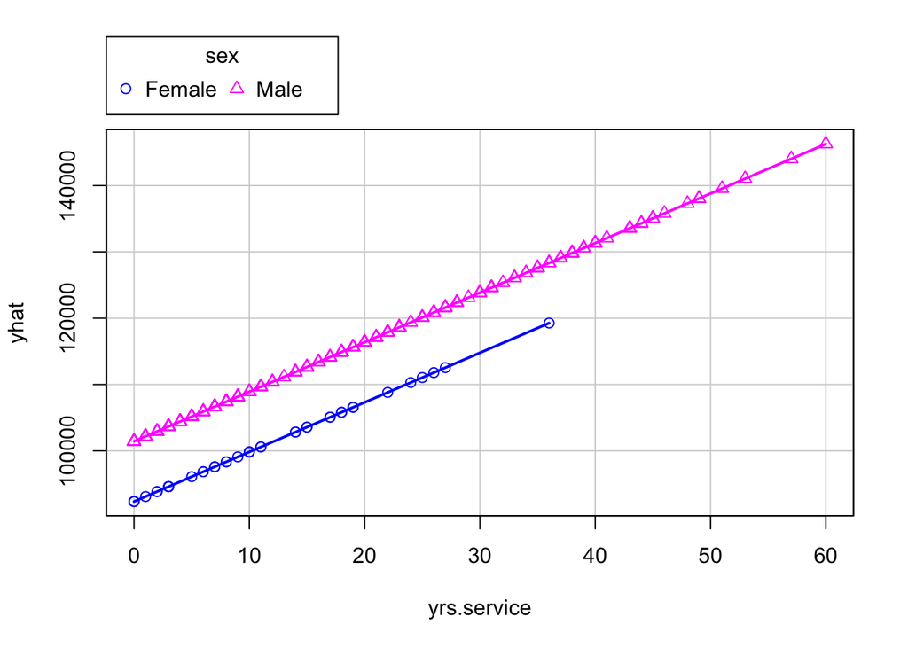

```r
yhat <- modelo1$fitted
scatterplot(yhat~yrs.service|sex, boxplots=FALSE, xlab="yrs.service", ylab="yhat",smooth=FALSE, data = Salaries)
```

Las pendientes de las dos líneas son las mismas, pero sus intersecciones, como se señaló anteriormente, son diferentes. Podemos interpretar la figura como: “Para dos personas con los mismo años de servicio, el profesor que es hombre tiene un ingreso esperado $\beta_1$ más que mujer”.

Otra forma de parametrizar este modelo es de la siguiente forma.

```r
modelo1.1 <- lm(salary ~ sex + yrs.service - 1 , data = Salaries )
summary(modelo1.1)
```

```
##
## Call:
## lm(formula = salary ~ sex + yrs.service - 1, data = Salaries)
##
## Residuals:
##    Min     1Q Median     3Q    Max
## -81757 -20614  -3376  16779 101707
##
## Coefficients:
##             Estimate Std. Error t value Pr(>|t|)
## sexFemale    92356.9     4740.2  19.484  < 2e-16 ***
## sexMale     101428.7     2531.9  40.060  < 2e-16 ***
## yrs.service    747.6      111.4   6.711 6.74e-11 ***
## ---
## Signif. codes:  0 '***' 0.001 '**' 0.01 '*' 0.05 '.' 0.1 ' ' 1
##
## Residual standard error: 28490 on 394 degrees of freedom
## Multiple R-squared:  0.9418, Adjusted R-squared:  0.9414
## F-statistic:  2126 on 3 and 394 DF,  p-value: < 2.2e-16
```

Como se puede observar, con esta parametrización, para las mujeres, el intercepto en el modelo es $\beta_0=$ 92,356.95 y para los hombres es $\beta_1=$ 101,428.7

## Variables Dummy para pendiente

También se pueden introducir variables ficticias para afectar la pendiente de un modelo de regresión. En lugar de suponer que el efecto del genero provoca un cambio en el intercepto en nuestro modelo anterior, supongamos que el cambio está en la pendiente de la relación. Para lograr esto, podemos permitir el cambio en una pendiente al incluir una variable explicativa adicional en nuestro modelo que sea igual al producto de una variable ficticia y una variable continua. En tal modelo, la pendiente de la relación es el valor de un aumento de una unidad en la experiencia laboral. Podemos especificar una forma genérica de tal modelo como

$$\begin{equation}
y = \beta_0 + \beta_1 x + \beta_2 (x \times D) +\epsilon
\end{equation}$$

La nueva variable $(x \times D)$ es el producto de $x$ y la variable ficticia $D$. Esto es lo que se llama una variable de interacción, ya que captura el efecto de interacción de la variable continua $x$ y la variable ficticia $D$. Alternativamente, también se la denomina variable indicadora de pendiente o variable ficticia de pendiente, porque permite un cambio en la pendiente de la relación. Usando nuestro ejemplo actual, nuestro modelo de regresión que describe los efectos de interacción de los años de servicio y el género se puede escribir como:

$$\begin{equation}
salary = \beta_0 + \beta_1 yrs.service + \beta_2 (yrs.service \times
sex) +\epsilon
\end{equation}$$

A pesar de su naturaleza inusual, la variable ficticia de pendiente se trata como cualquier otra variable explicativa en un modelo de regresión. El análisis del modelo de regresión para los dos grupos individuales diferentes ilustra mejor el efecto de la inclusión de la variable ficticia de pendiente en el modelo económico.

Para los hombres, su ingreso por año adicional de servicio es $(\beta_1+\beta_2)$, mientras que para las mujeres, el ingreso por año adicional de servicio es simplemente $\beta_1$.

$$\begin{equation}
E(salary) = \beta_0 + \beta_1 yrs.service + \beta_2 (yrs.service
\times sex) =
\begin{cases}
\beta_0 + (\beta_1+\beta_2) yrs.service & sex=Male=1\\
\beta_0+\beta_1 yrs.service & sex=Female=0
\end{cases}
\end{equation}$$

Otra forma de ver el efecto de incluir una variable ficticia de pendiente es usar un poco de cálculo. La derivada parcial de los ingresos esperados con respecto a los años de servicio nos da la pendiente de la relación. Eso es,

$$\begin{equation}
\frac{\partial E(salary)}{\partial yrs.service } =
\begin{cases}
(\beta_1+\beta_2) & \text{cuando }sex=Male=1\\
\beta_1 & \text{cuando }sex=Female=0
\end{cases}
\end{equation}$$

```r
modelo2 <- lm(salary ~ yrs.service + sex:yrs.service , data = Salaries )
summary(modelo2)
```

```
##
## Call:
## lm(formula = salary ~ yrs.service + sex:yrs.service, data = Salaries)
##
## Residuals:
##    Min     1Q Median     3Q    Max
## -82107 -20672  -3554  16414 101778
##
## Coefficients:
##                     Estimate Std. Error t value Pr(>|t|)
## (Intercept)         100125.4     2444.6  40.957   <2e-16 ***
## yrs.service            640.2      344.1   1.860   0.0636 .
## yrs.service:sexMale    139.9      327.0   0.428   0.6691
## ---
## Signif. codes:  0 '***' 0.001 '**' 0.01 '*' 0.05 '.' 0.1 ' ' 1
##
## Residual standard error: 28610 on 394 degrees of freedom
## Multiple R-squared:  0.1125, Adjusted R-squared:  0.108
## F-statistic: 24.96 on 2 and 394 DF,  p-value: 6.201e-11
```

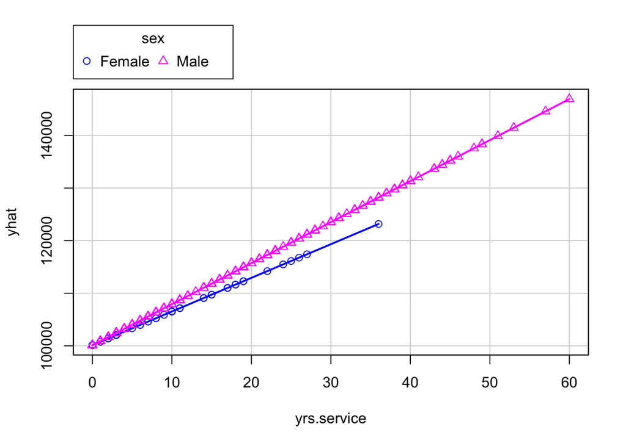

```r
yhat <- modelo2$fitted
scatterplot(yhat~yrs.service|sex, boxplots=FALSE, xlab="yrs.service", ylab="yhat",smooth=FALSE, data = Salaries)
```

```r
modelo3 <- lm(salary ~ sex+ yrs.service + sex:yrs.service, data = Salaries )
summary(modelo3)
```

```
##
## Call:
## lm(formula = salary ~ sex + yrs.service + sex:yrs.service, data = Salaries)
##
## Residuals:
##    Min     1Q Median     3Q    Max
## -80381 -20258  -3727  16353 102536
##
## Coefficients:
##                     Estimate Std. Error t value Pr(>|t|)
## (Intercept)          82068.5     7568.7  10.843  < 2e-16 ***
## sexMale              20128.6     7991.1   2.519  0.01217 *
## yrs.service           1637.3      523.0   3.130  0.00188 **
## sexMale:yrs.service   -931.7      535.2  -1.741  0.08251 .
## ---
## Signif. codes:  0 '***' 0.001 '**' 0.01 '*' 0.05 '.' 0.1 ' ' 1
##
## Residual standard error: 28420 on 393 degrees of freedom
## Multiple R-squared:  0.1266, Adjusted R-squared:  0.1199
## F-statistic: 18.98 on 3 and 393 DF,  p-value: 1.622e-11
```

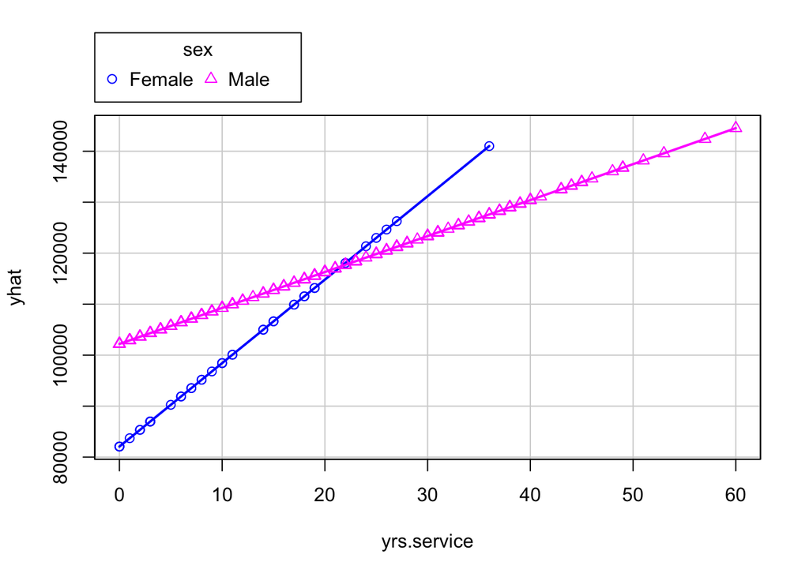

```r
yhat <- modelo3$fitted
scatterplot(yhat~yrs.service|sex, boxplots=FALSE, xlab="yrs.service", ylab="yhat",smooth=FALSE, data = Salaries)
```

```r
modelo3 <- lm(salary ~ sex+ yrs.service + sex:yrs.service -1,
              data = Salaries )
summary(modelo3)
```

```
##
## Call:
## lm(formula = salary ~ sex + yrs.service + sex:yrs.service - 1,
##     data = Salaries)
##
## Residuals:
##    Min     1Q Median     3Q    Max
## -80381 -20258  -3727  16353 102536
##
## Coefficients:
##                     Estimate Std. Error t value Pr(>|t|)
## sexFemale            82068.5     7568.7  10.843  < 2e-16 ***
## sexMale             102197.1     2563.7  39.863  < 2e-16 ***
## yrs.service           1637.3      523.0   3.130  0.00188 **
## sexMale:yrs.service   -931.7      535.2  -1.741  0.08251 .
## ---
## Signif. codes:  0 '***' 0.001 '**' 0.01 '*' 0.05 '.' 0.1 ' ' 1
##
## Residual standard error: 28420 on 393 degrees of freedom
## Multiple R-squared:  0.9423, Adjusted R-squared:  0.9417
## F-statistic:  1604 on 4 and 393 DF,  p-value: < 2.2e-16
```

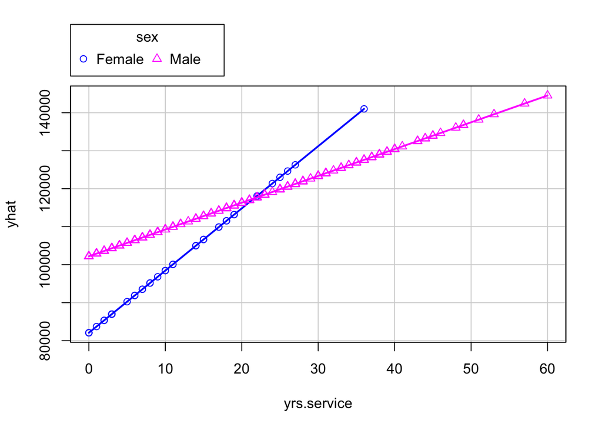

```r
yhat <- modelo3$fitted
scatterplot(yhat~yrs.service|sex, boxplots=FALSE, xlab="yrs.service", ylab="yhat",smooth=FALSE, data = Salaries)
```

```r
modelo4 <- lm(salary ~ yrs.since.phd + discipline:yrs.since.phd,
              data = Salaries )
summary(modelo4)
```

```
##
## Call:
## lm(formula = salary ~ yrs.since.phd + discipline:yrs.since.phd,
##     data = Salaries)
##
## Residuals:
##    Min     1Q Median     3Q    Max
## -86624 -18023  -2726  15476  91627
##
## Coefficients:
##                           Estimate Std. Error t value Pr(>|t|)
## (Intercept)                89426.7     2683.8  33.321  < 2e-16 ***
## yrs.since.phd                791.3      108.2   7.311 1.49e-12 ***
## yrs.since.phd:disciplineB    616.5      104.9   5.879 8.82e-09 ***
## ---
## Signif. codes:  0 '***' 0.001 '**' 0.01 '*' 0.05 '.' 0.1 ' ' 1
##
## Residual standard error: 26430 on 394 degrees of freedom
## Multiple R-squared:  0.2422, Adjusted R-squared:  0.2384
## F-statistic: 62.97 on 2 and 394 DF,  p-value: < 2.2e-16
```

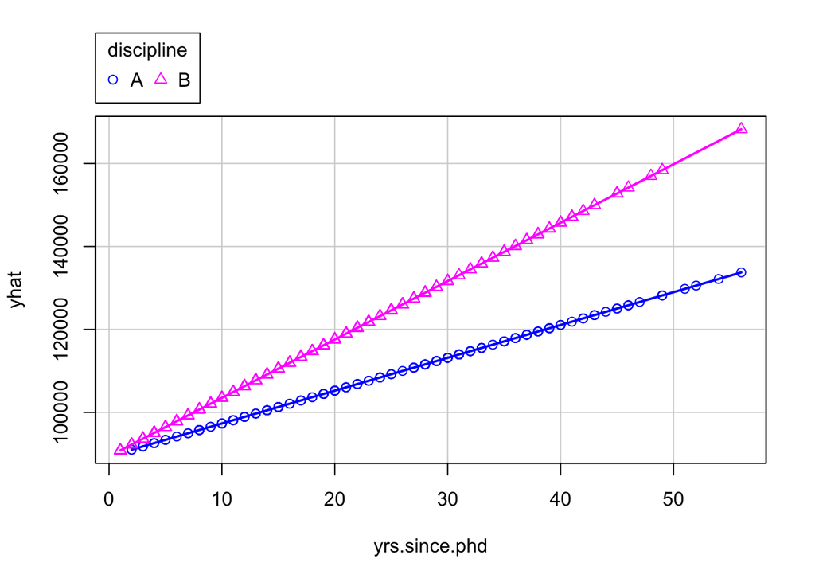

```r
yhat <- modelo4$fitted
scatterplot(yhat~yrs.since.phd|discipline, boxplots=FALSE, xlab="yrs.since.phd", ylab="yhat",smooth=FALSE, data = Salaries)
```